# Relatório log-normal e gamma

Maria Luísa de Medeiros Falcão

2025-10-20

## 1 Introdução

Dentro de modelos lineares generalizados (GLMs), quando se tem variáveis contínuas e positiva costuma-se usar distribuições que como Gamma e Log Normal. A distribuição Gamma é apropriada para modelar variáveis assimétricas à direita, sendo frequentemente aplicada em dados de taxas, tempos ou produtividades. Já a distribuição Log-Normal é usada quando o logaritmo da variável resposta segue uma distribuição normal, também representando dados positivos.

Para exemplificarmos essas duas distribuições usaremos um conjunto de dados de pesca, armazenados no diretório `/Dados` da disciplina.

```r
#~~~~~~~~~~~~~~~~~~~~~~~~~~~~~~~~
# 1. Definindo diretório e importando o banco de dados
#~~~~~~~~~~~~~~~~~~~~~~~~~~~~~~~~
setwd("/Users/mcruf/Library/CloudStorage/OneDrive-Personal/Arbeit/Lectures_and_Talks/UFRN/Lectures/ECL0072-GLM_GAM")
dados <- readRDS("Dados/fisheries.rds")
```

Banco de dados simulado que descreve uma típica pescaria de atum no Oceano Atlântico Sul. Nesse banco de dados temos informações de fatores oceanográficos, espaciais, sazonais e pesqueiros.

Vejamos a estrutura dos dados:

```r
#~~~~~~~~~~~~~~~~~~~~~~~~~~
# 2. Análise exploratória
#~~~~~~~~~~~~~~~~~~~~~~~~~~
str(dados)
```

```
## 'data.frame':    476 obs. of  33 variables:
##  $ Ano                     : int  2003 2003 2003 2003 2003 2003 2003 2003 2003 2003 ...
##  $ Mes                     : int  1 1 1 1 1 1 1 1 1 1 ...
##  $ N_anzol                 : int  1050 1050 1050 1050 1050 980 955 960 960 1052 ...
##  $ Barco                   : chr  "V201" "V201" "V201" "V201" ...
##  $ Pais                    : Factor w/ 3 levels "A","B","C": 2 2 2 2 2 2 2 2 2 2 ...
##  $ Long                    : num  -33.3 -38.8 -38.1 -35.8 -36.9 ...
##  $ Lat                     : num  -27.855 0.399 -15.695 -1.997 -19.667 ...
##  $ Thunnus_albacares       : num  4 27 5 55 7 11 29 58 6 14 ...
##  $ Thunnus_atlanticus      : num  0 32 0 0 4 18 0 0 4 13 ...
##  $ Katsuwonus_pelamis      : num  5 0 7 0 5 0 36 0 0 7 ...
##  $ Xiphias_gladius         : num  0 0 0 0 0 0 0 0 2 0 ...
##  $ Istiophorus_albicans    : num  3 0 0 11 0 5 0 12 3 0 ...
##  $ Tetrapturus_albidus     : num  3 6 0 0 2 7 0 0 2 0 ...
##  $ Makaira_nigricans       : num  0 0 0 0 0 0 0 0 0 0 ...
```

[output cut: 19 more lines]

## 2 Relacionando a fatores espaço-temporais

### 2.1 Transformando as variáveis

Vamos transformar as variáveis que foram importadas como character para factor

- Isso permitirá que os níveis do fator possam ser comparados (graficamente e estatisticamente)

```r
# 2.1) Convertendo as variáveis
#~~~~~~~~~~~~~~~~~~~~~~~~~~~~~~~
dados[, c("Ano", "Mes", "Barco")] <- lapply(dados[, c("Ano", "Mes", "Barco")], factor)
```

Agora vamos selecionar as espécies alvos

```r
## Espécies alvo (atuns)
especies_alvo <- c("Thunnus_albacares",
                   "Thunnus_atlanticus",
                   "Katsuwonus_pelamis",
                   "Prionace_glauca")
```

Próximo passo será calcular a abundância total das espécies alvos padronizando pelo esforço (CPUE)

```r
## Calculando a abundância total de espécies alvo
### E padronizando pelo esforço (CPUE = Catch Per Unit of Effort)
dados <- dados %>%
  rowwise() %>%  # linha a linha
  mutate(
    Catch = sum(c_across(all_of(especies_alvo))),  # soma da abundância das espécies alvo
    CPUE = Catch / N_anzol   # padronização por esforço (número de anzóis)
  ) %>%
  data.frame()
```

Temos que nos certificar se não há presença de zeros, já que as distribuições de gama e de log normal não comportam 0 na variável resposta (Y)

```r
#Visulizando os dados

summary(dados$CPUE) #Tem zero
```

```
##    Min. 1st Qu.  Median    Mean 3rd Qu.    Max.
## 0.00000 0.01273 0.02091 0.03873 0.05528 0.18046
```

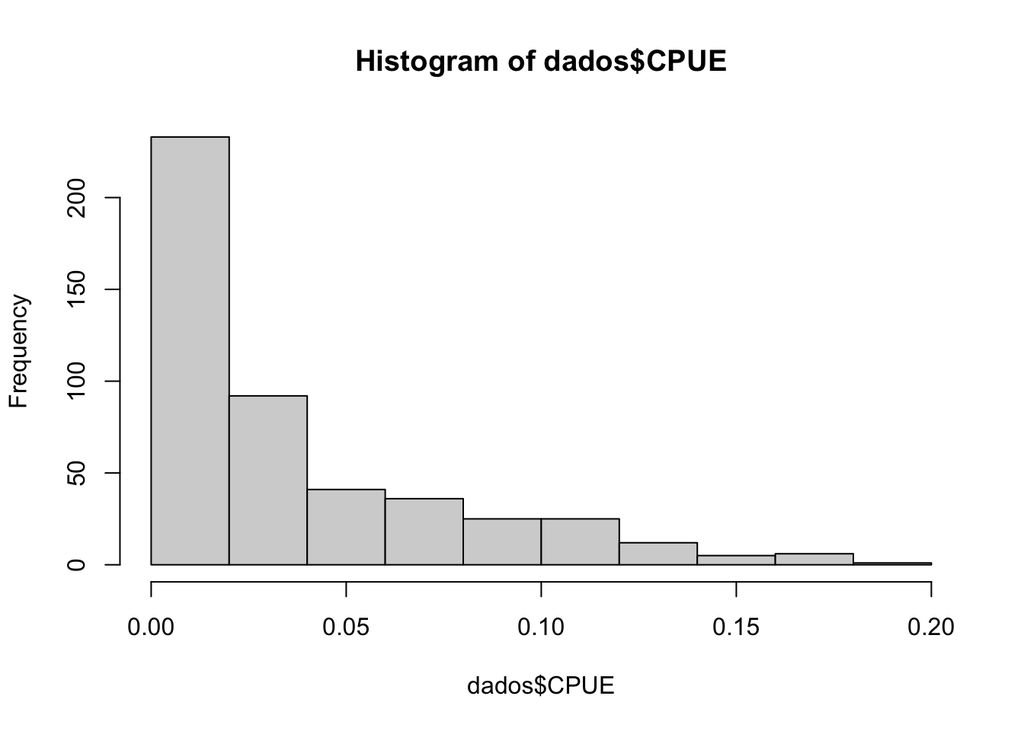

```r
hist(dados$CPUE)
```

Vemos que tem zero, então pra contornar essa situação, podemos usar um truque matemático: adicionar uma pequena constante (e.g., 10% da mediana).

```r
dados$CPUE2 <- dados$CPUE + (0.1 * median(dados$CPUE))
```

Podemos começar a montar nossos primeiros modelos. Primeiramente relacionaremos o CPUE com fatores espaço temporais usando distribuição Gamma e log Normal. A função glmmTMB é a estrutura desse modelo, voce indica a formula, o modelo e os dados. Aqui só colocamos o fator temporal e espacial. Na parte de família especificamos pra log, porque no glmmTMB ele usa o identidade ao invés de log. A função de ligação canônica é a log (canônica: é a função de ligação mais natural que voce pode estabelecer entre o componente aleatório e componente sistemático/fixo, tem que colocar aqui “link = log” porque o default do pacote pra quando usa a família Gamma é inversa)

```r
modelo_Gamma <- glmmTMB(CPUE2 ~ Mes + Lat+Long,
                    family = Gamma(link = "log"),
                    data = dados)


## Modelo log-Normal ##
modelo_LogN <- glmmTMB(CPUE2 ~ Mes + Lat + Long,
                     family = lognormal(link = "log"),
                     data = dados)
```

Para compararos modelos rodamos um AIC

```r
AIC(modelo_Gamma, modelo_LogN) #Pelo o AIC o Gamma foi melhor
```

```
##              df       AIC
## modelo_Gamma 15 -2530.973
## modelo_LogN  15 -2337.802
```

Segundo o AIC, o melhor modelo foi o Gamma. Para além disso, agora avaliaremos os resíduos dos modelos.

```r
## simulando os residuos
resGamma <- simulateResiduals(modelo_Gamma, n=1000)
resLogN <- simulateResiduals(modelo_LogN, n=1000)
```

Para vermos visualmente como esses resíduos se comportam usamos essa função:

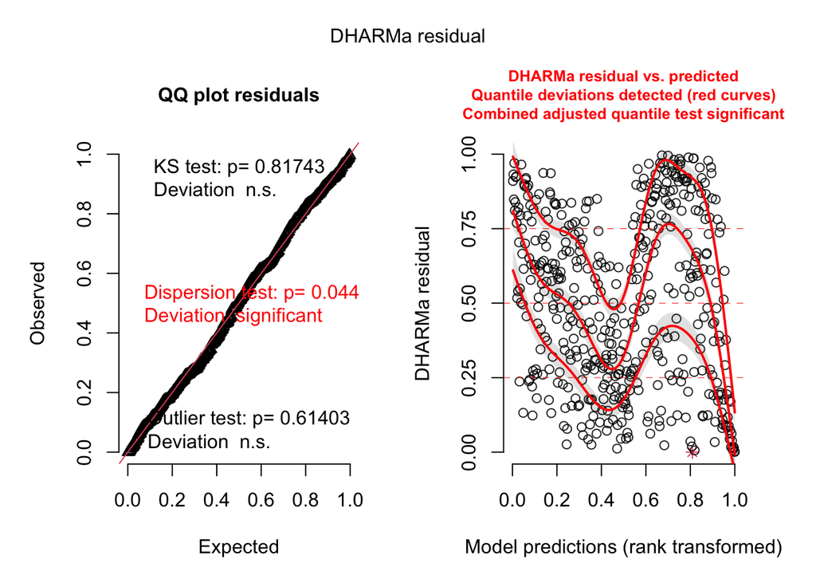

```r
plot(resGamma)
```

No primeiro gráfico, o de QQ plot residuals, vemos que os dados estão bem concentrados na linha diagonal, o que pode indicar que o modelo está bem ajustado, porém no segundo gráfico as linhas vermelhas estão demostrando um certo padrão, então talvez o modelo não esteja bem ajustado. E o KStest deu p > 0.05, então não rejeitamos a hipótese nula, ou seja, os dados seguem a distribuição esperada. O modelo não está “perfeito”, porque o padrão de ondas mostra que há não-linearidades ou efeitos faltantes que o modelo não está capturando.

Agora iremos avaliar como ficou o do Log normal

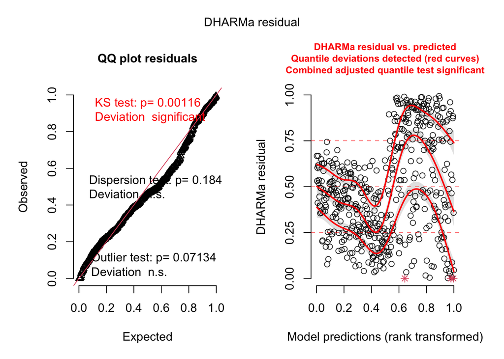

```r
plot(resLogN)
```

Nesse daqui vemos que o QQplot residuals os dados fogem ligeriamente da linha diagonal. E quanto ao residual vs predicted também apresenta um padrão também. E o KS test também deu p<0.05, então aceitamos a hipótese alternativa de que os resíduos não seguem a distribuição esperada.

Para avaliarmos o comportamento geral dos resíduos usamos o “check_model”

```r
check_model(modelo_Gamma)
```

```
## `check_outliers()` does not yet support models of class `glmmTMB`.
```

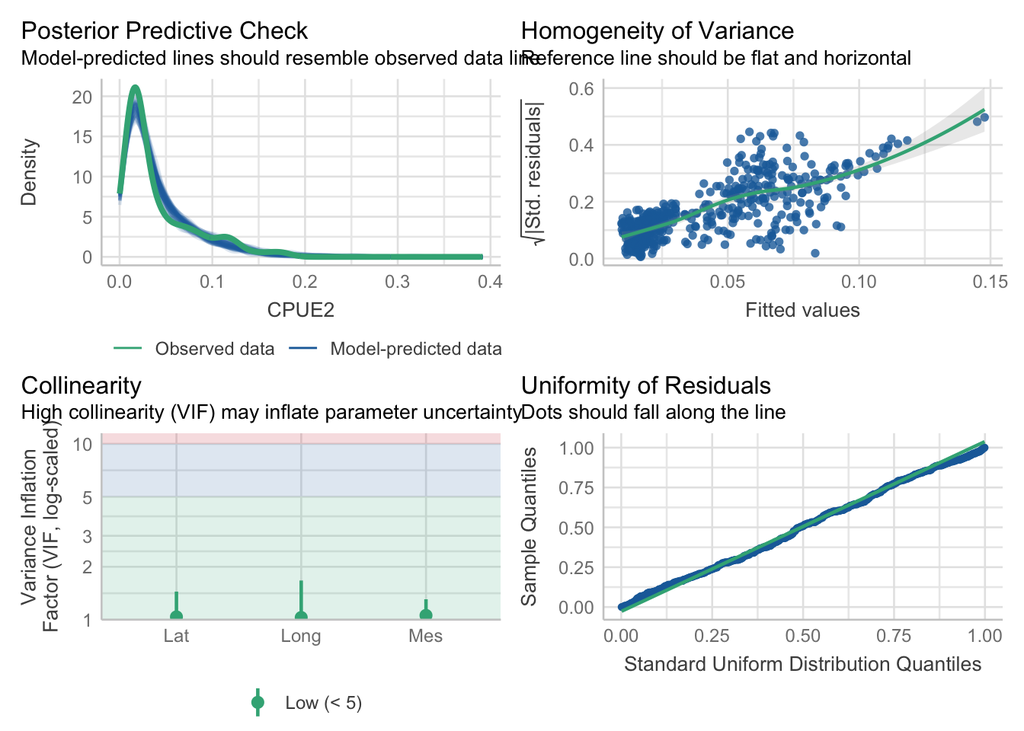

Pelo gráfico do posterior predictive check o modelo está subestimando um pouco os dados. Observe que no gráfico de homogeneidade da variância, tem um leve padrão, que a variância aumenta, mas ela aumenta somente para poucos dados, ou seja para valores preditos mais altos. Porém a maioria dos resíduos se concentra em valores preditos baixos e médios, com variância aproximadamente constante. Pelo gráfico de colinearidade eles não apresentam ser correlacionados. Pela distribuição de quantis de resíduos, podemos ver que os dados estão bem próximos a linha diagonal, ou seja, significa que os resíduos seguem bem a distribuição esperada.

Vamos ver como ficou para o modelo Log normal

```r
check_model(modelo_LogN)
```

```
## `check_outliers()` does not yet support models of class `glmmTMB`.
```

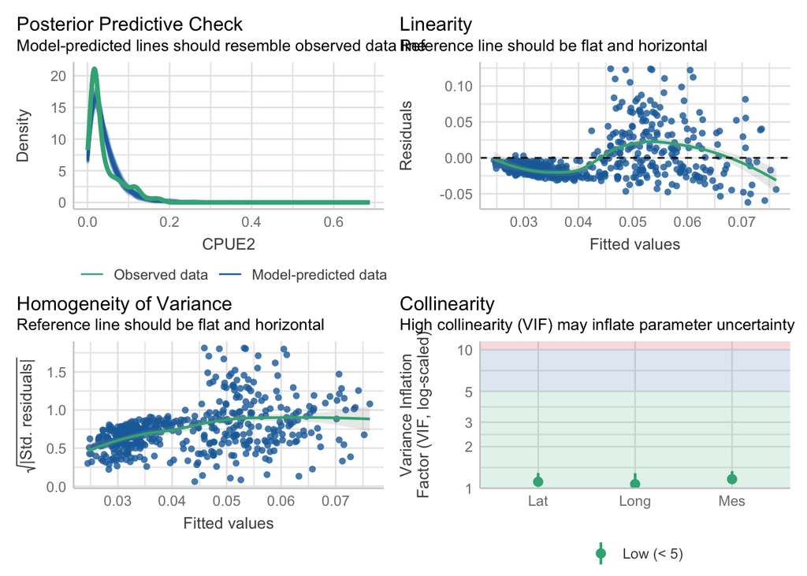

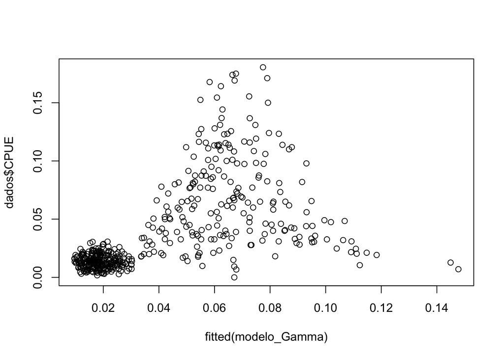

```r
plot(dados$CPUE~fitted(modelo_Gamma)) #talvez apagar
```

Precisamos agora analisar se há correlação espacial (entre long e lat):

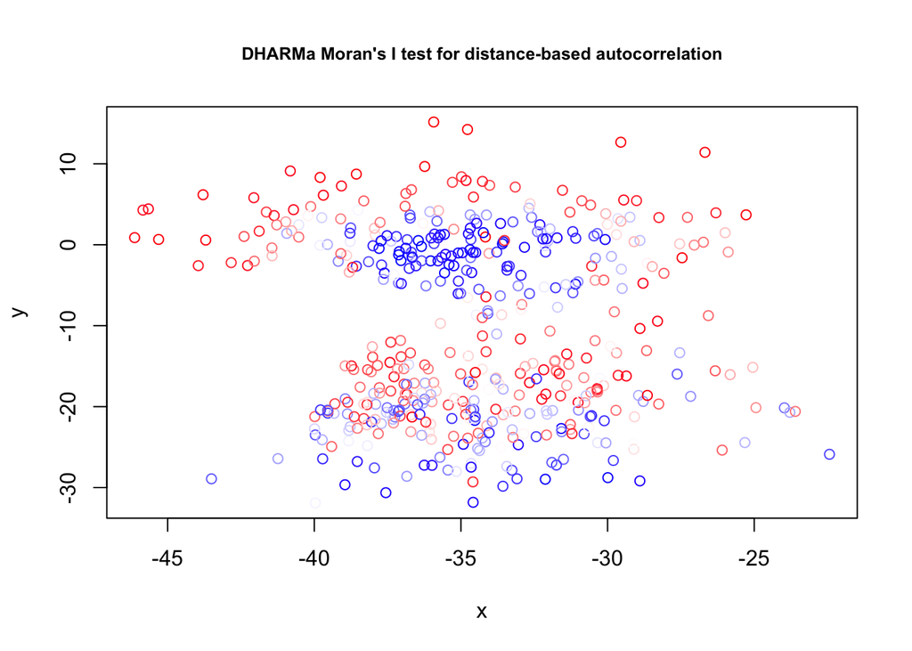

```
##
##  DHARMa Moran's I test for distance-based autocorrelation
##
## data:  resGamma
## observed = 0.1344979, expected = -0.0021053, sd = 0.0044823, p-value <
## 2.2e-16
## alternative hypothesis: Distance-based autocorrelation
```

```r
testSpatialAutocorrelation(resGamma, x = dados$Long, y = dados$Lat)
```

Esse teste avalia a autocorrelação dos resíduos do modelo — ou seja, verificam se os resíduos próximos no espaço ou no tempo (como faremos adiante) são parecidos demais. Pelo que podemos ver apresenta uma certa autocorrelação pois os dados demostram ter um padrão. Além disso o valor de p deu menor < 0.05, O que rejeita a hipóteses nula de que a autocorrelação seria ausente. Por terem apresentado autocorrelação espacial significativa (Moran’s I = 0.13, p < 0.001), indica que há dependência espacial não explicada. Assim, os resultados devem ser interpretados com cautela, pois parte da variação da CPUE pode estar associada à localização geográfica das capturas.

Próximo passo é avaliar se há correlação temporal

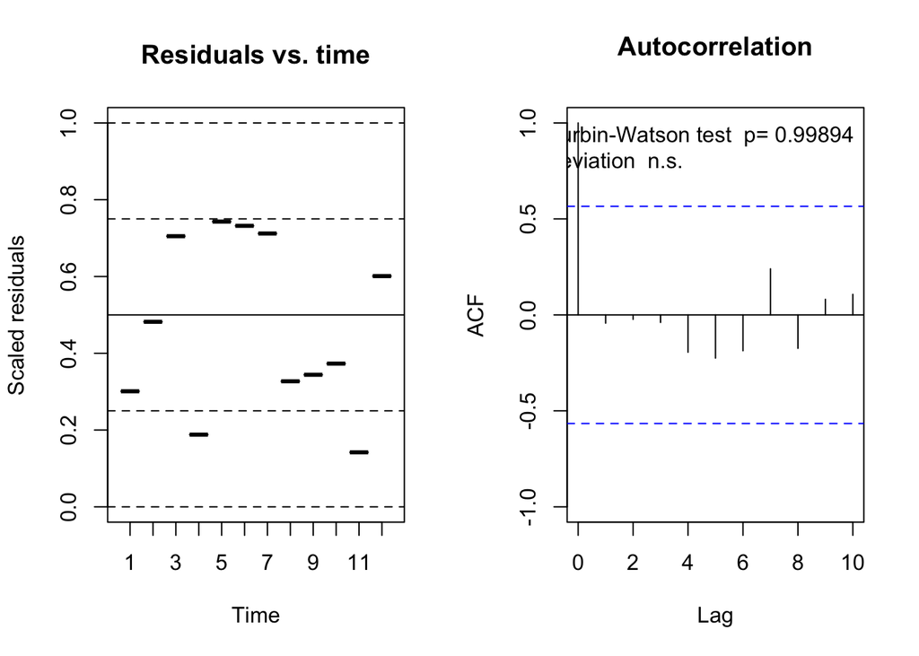

```
##
##  Durbin-Watson test
##
## data:  simulationOutput$scaledResiduals ~ 1
## DW = 2.0007, p-value = 0.9989
## alternative hypothesis: true autocorrelation is not 0
```

```r
res <- recalculateResiduals(resGamma, group = dados$Mes)
testTemporalAutocorrelation(res, time = unique(dados$Mes))
```

Pelos gráficos gerados há uma indicação de que não há autocorrelação temporal significativa nos resíduos. Isso sugere que o modelo está lidando bem com a estrutura temporal dos dados. Além disso p deu maior que 0.05, então se mantem a hipótese nula de ausência de autocorrelação  
O melhor modelo segundo o AIC foi o gamma, então iremos agora ver o summary dele

```r
summary(modelo_Gamma)
```

```
##  Family: Gamma  ( log )
## Formula:          CPUE2 ~ Mes + Lat + Long
## Data: dados
##
##       AIC       BIC    logLik -2*log(L)  df.resid
##   -2531.0   -2468.5    1280.5   -2561.0       461
##
##
## Dispersion estimate for Gamma family (sigma^2): 0.315
##
## Conditional model:
##               Estimate Std. Error z value Pr(>|z|)
## (Intercept) -3.3094247  0.2789341 -11.865   <2e-16 ***
## Mes2         0.0835699  0.1375682   0.607   0.5435
## Mes3         0.2507218  0.1394545   1.798   0.0722 .
## Mes4         0.0211155  0.1369415   0.154   0.8775
## Mes5         0.1061553  0.1354538   0.784   0.4332
## Mes6         0.2497234  0.1302361   1.917   0.0552 .
## Mes7         0.1219539  0.1337727   0.912   0.3620
## Mes8         0.0784646  0.1306664   0.600   0.5482
## Mes9         0.1751390  0.1308352   1.339   0.1807
## Mes10        0.0007293  0.1324920   0.006   0.9956
## Mes11        0.0727408  0.1337443   0.544   0.5865
## Mes12        0.0768170  0.1411017   0.544   0.5862
## Lat          0.0610903  0.0023576  25.912   <2e-16 ***
## Long        -0.0125203  0.0074280  -1.686   0.0919 .
## ---
## Signif. codes:  0 '***' 0.001 '**' 0.01 '*' 0.05 '.' 0.1 ' ' 1
```

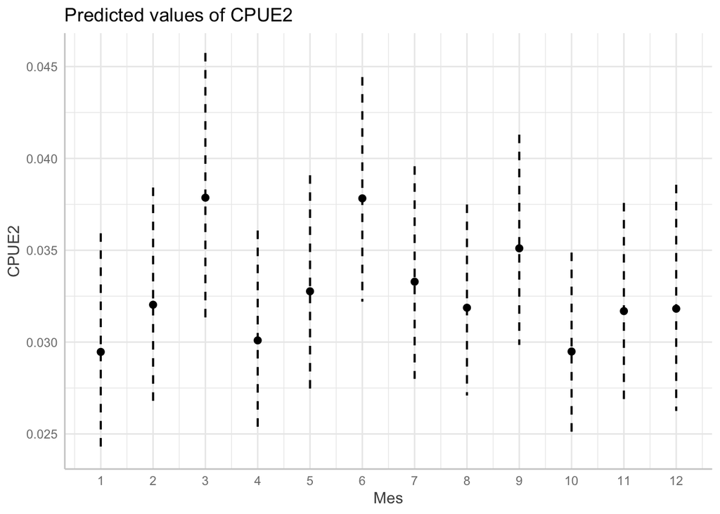

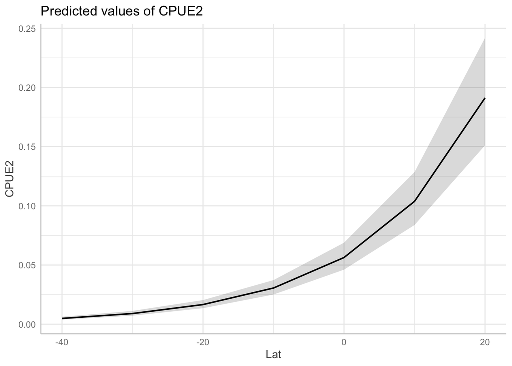

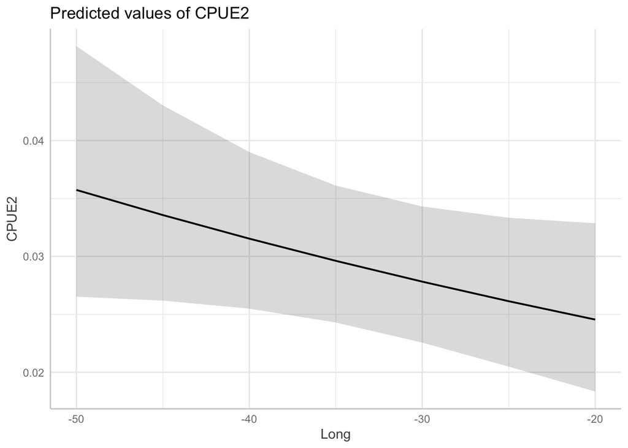

```r
library(ggeffects)
ggpredict(modelo_Gamma) %>% plot()
```

Como podemos ver os meses não tem uma variação muito grande, mas o mês 3 e 6 apresentam uma CPUE2 mais alta, isso pode ser devido o fato de ambos terem tido valores marginalmente próximos de p < 0.05 No segundo gráfico vemos a relação com a latitude, ela se mostra positiva, ou seja, a medida que a latitude aumenta CPUE2 também aumenta Para longitude esse efeito por mais que seja relativamente fraco, ele se mostra ser negativo.

## 3 Relacionando a fatores oceanográficos

Novamente faremos dois modelos, um de log Normal e outro de Gamma

```r
modelo_GammaOc <- glmmTMB(CPUE2 ~ depth + sal + chla,
                        family = Gamma(link = "log"),
                        data = dados)
## Modelo log-Normal ##
modelo_LogNOc <- glmmTMB(CPUE2 ~ depth + sal + chla,
                       family = lognormal(link = "log"),
                       data = dados)
```

Tiraremos o AIC dos dois para compará-los

```r
AIC(modelo_GammaOc, modelo_LogNOc)
```

```
##                df       AIC
## modelo_GammaOc  5 -2122.802
## modelo_LogNOc   5 -2187.223
```

Pelo resultado o modelo logNormal é o melhor. Por via de curiosidade vamos explorar modelos de log normal com outras variáveis

```r
modelo_LogNOcDLM <- glmmTMB(CPUE2 ~ depth + dlm + chla,
                         family = lognormal(link = "log"),
                         data = dados)
modelo_LogNOcDLM_dlm <- glmmTMB(CPUE2 ~ depth + dlm, family = lognormal(link = "log"), data = dados)
modelo_LogNOcDLM_chla <- glmmTMB(CPUE2 ~ depth + chla, family = lognormal(link = "log"), data = dados)
```

E iremos comparar mais uma vez usando o AIC

```r
AIC(modelo_GammaOc, modelo_LogNOc, modelo_LogNOcDLM, modelo_LogNOcDLM_chla, modelo_LogNOcDLM_dlm)
```

```
##                       df       AIC
## modelo_GammaOc         5 -2122.802
## modelo_LogNOc          5 -2187.223
## modelo_LogNOcDLM       5 -2190.367
## modelo_LogNOcDLM_chla  4 -2188.128
## modelo_LogNOcDLM_dlm   4 -2187.055
```

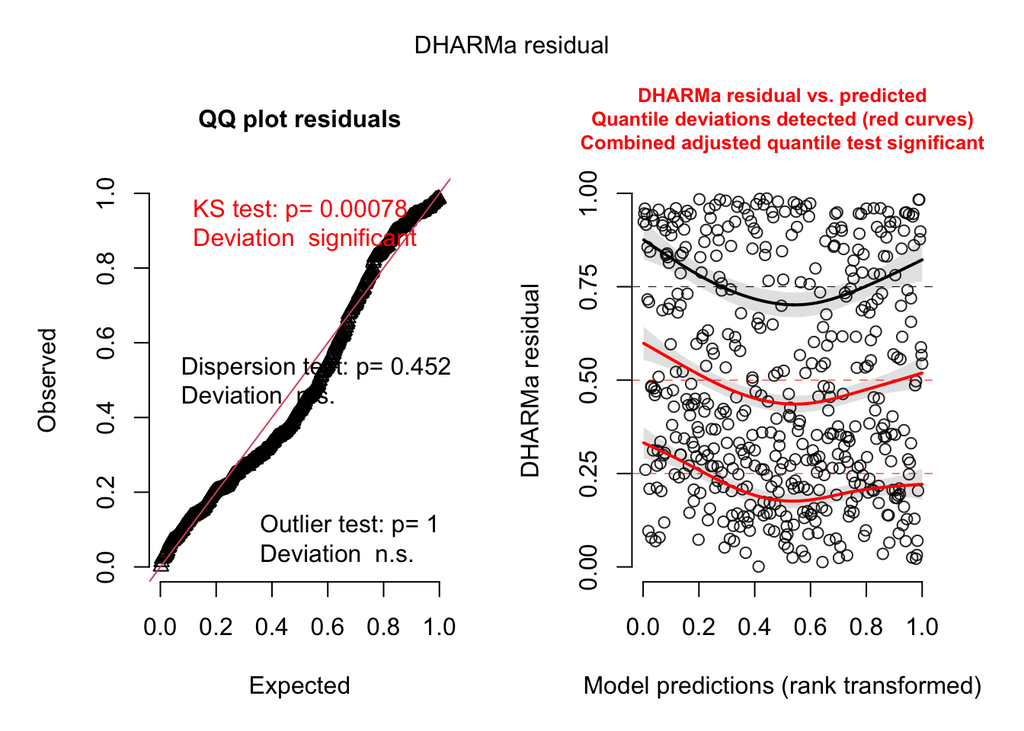

```r
resLogNOcDLM <- simulateResiduals(modelo_LogNOcDLM, n=1000)
plot(resLogNOcDLM)
```

```r
check_model(modelo_LogNOcDLM)
```

```
## `check_outliers()` does not yet support models of class `glmmTMB`.
```

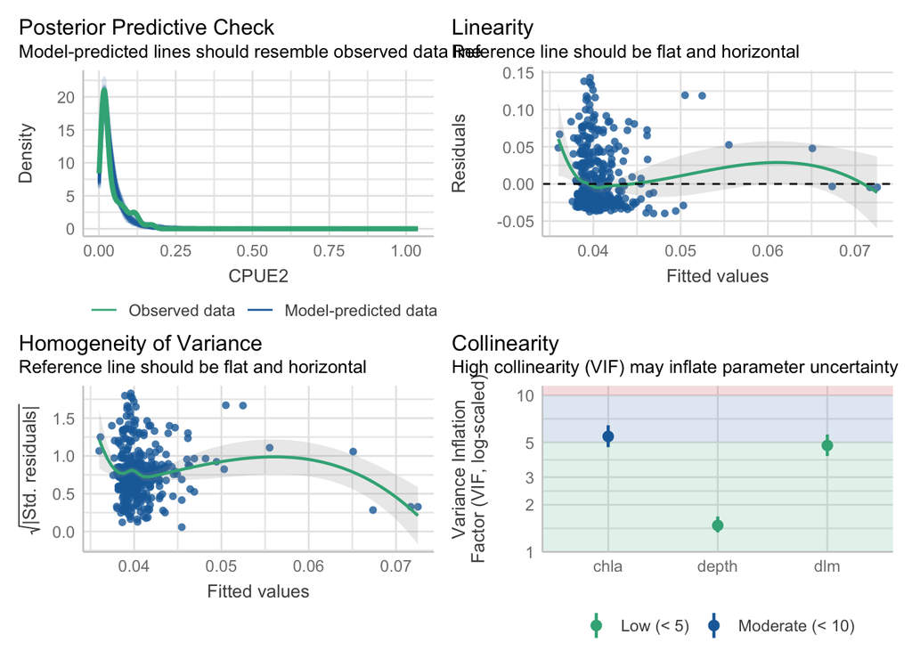

Aqui vemos que no geral os resíduos estão bem distribuídos, porém apresenta alguns poucos valores que puxam a linha de referência pra cima ou pra baixo, como no caso do gráfico de linearidade e de homogeneidade. Agora quando vemos o de colinearidade, chla apresenta colinearidade moderada, ou seja, então os coeficientes podem ser ligeiramente instáveis, interpretar chla isoladamente deve ser feito com cuidado.  
Vamos ver se essa colinearidade é referente a dlm

```r
cor(dados$dlm, dados$chla, use = "complete.obs")
```

```
## [1] 0.8688255
```

Colinearidade r> 0.7 colinearidade alta, ou seja, elas carregam informação similar sobre a variação de CPUE2. Isso vai tornar a interpretação isolada complicada, pois não dá para dizer com certeza que o efeito de chla é independente de dlm, porque eles “competem” para explicar a mesma variação.  
Vamos ver o summary desse modelo

```r
summary(modelo_LogNOcDLM)
```

```
##  Family: lognormal  ( log )
## Formula:          CPUE2 ~ depth + dlm + chla
## Data: dados
##
##       AIC       BIC    logLik -2*log(L)  df.resid
##   -2190.4   -2169.5    1100.2   -2200.4       471
##
##
## Dispersion parameter for lognormal family (): 0.0428
##
## Conditional model:
##               Estimate Std. Error z value Pr(>|z|)
## (Intercept) -3.103e+00  1.880e-01 -16.507  < 2e-16 ***
## depth       -1.683e-05  2.539e-05  -0.663  0.50747
## dlm         -7.100e-03  3.162e-03  -2.245  0.02476 *
## chla         2.534e+00  9.266e-01   2.735  0.00624 **
## ---
## Signif. codes:  0 '***' 0.001 '**' 0.01 '*' 0.05 '.' 0.1 ' ' 1
```

O intercepto é o valor esperado da variável resposta (CPUE2) quando todas as variáveis preditoras estão em zero. Lembre que esses valores estão em log. Depth não parece afetar a CPUE de forma detectável, pois tem p> 0.05. DLM parece afetar CPUE2 de forma negativa, ou seja quanto maior dlm, menor a CPUE2. Chla também aparenta apresentar efeito sob CPUE2, de forma positiva, ou seja quanto maior um maior o outro. Porém, dlm e chla estão fortemente correlacionados, portanto esses efeitos individuais devem ser interpretados com cautela, já que o modelo tem dificuldade em separar completamente suas influências.  
Agora geraremos valores preditos da CPUE2 para cada preditor, mantendo os outros preditores em seus valores médios (ou referência).

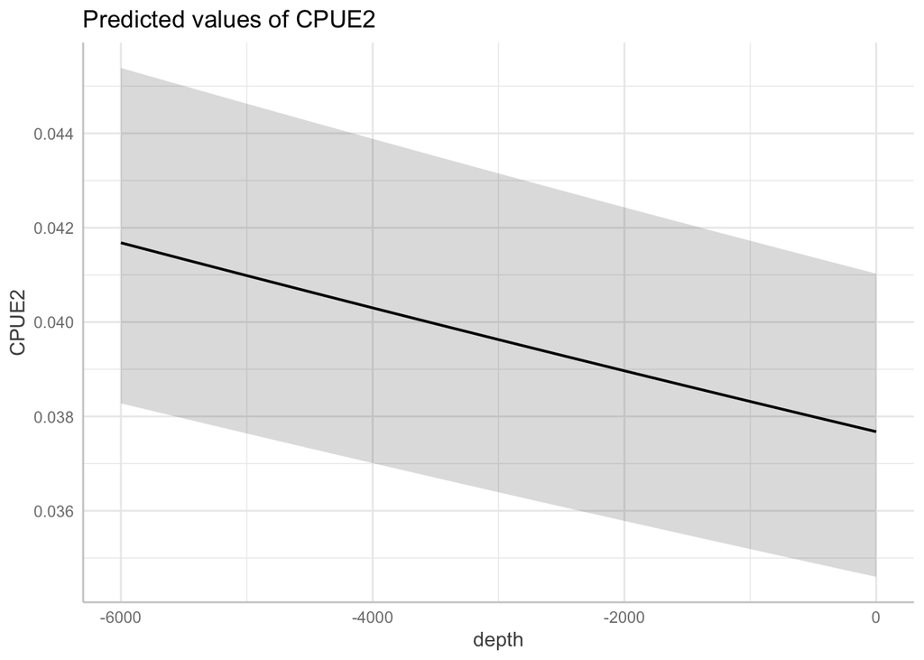

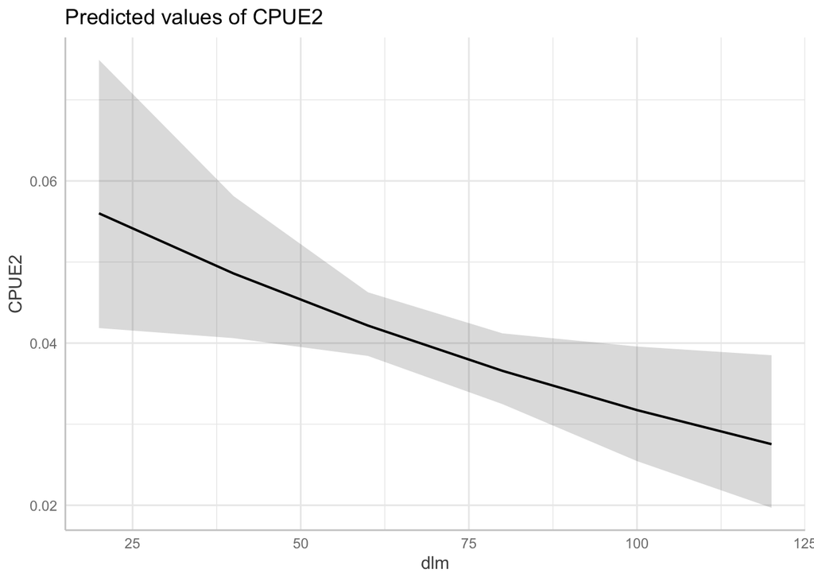

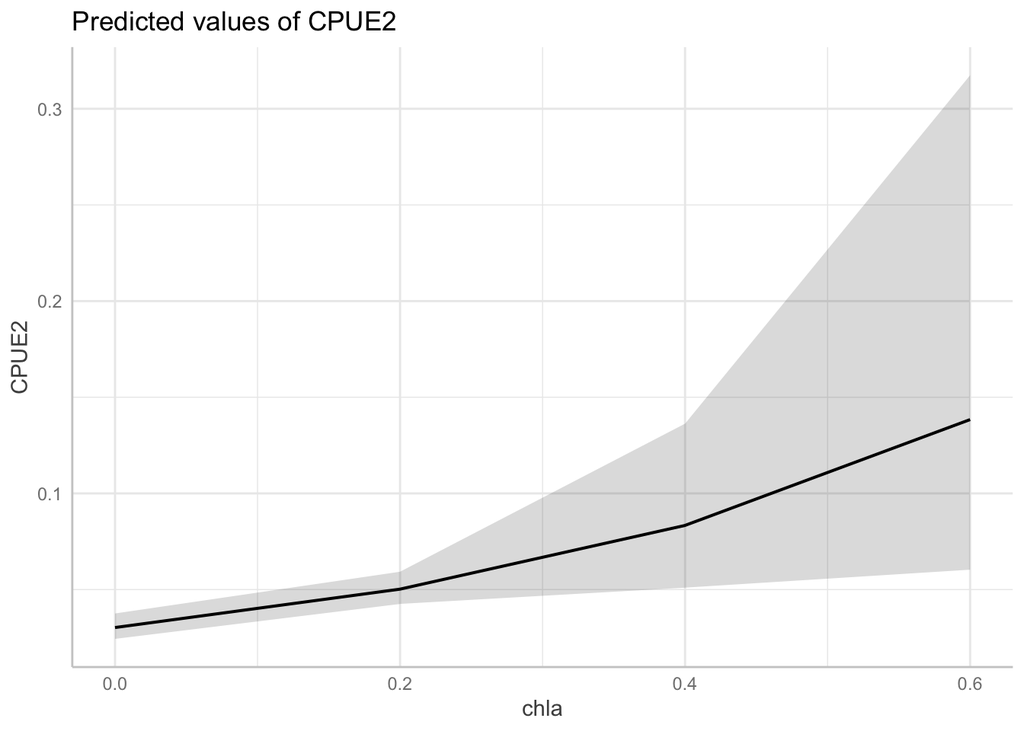

```r
ggpredict(modelo_LogNOcDLM) %>% plot()
```

Lembrando que chla e dlm possuem colinearidade considerável. Os gráficos mostram o efeito isolado de dlm e chla sobre CPUE2 (algo que não ocorre naturalmente nos dados, já que eles apresentam alta colinearidade), mantendo a outra variável constante. Devido a colinearidade de ambos, esses efeitos isolados devem ser interpretados com cautela. No primeiro gráfico gerado, temos a profundidade e CPUE2, como vimos profundidade não parece afetar tanto CPUE2, talvez por isso vemos uma variação pequena. O que poderia se interpretar desse gráfico seria: Quanto mais profundo, maior a CPUE2; quanto mais raso, menor a CPUE2. Já no segundo gráfico, dlm: camada de mistura de massas de água com CPUE2, quanto maior CPUE2 menor CPUE2. Já para chla (clorofila) quanto maior a concentração de clorofila maior CPUE2

## 4 Modelo pesqueiro

Agora faremos modelos considerando variáveis pesqueiras e sua influência sobre CPUE2. Novamente compararemos modelos gamma com lognormal

```r
modelo_GammaPesq <-  glmmTMB(CPUE2 ~ Barco + N_anzol + Catch,
                             family = Gamma(link = "log"),
                             data = dados)
## Modelo log-Normal ##
modelo_LogNPesq <- glmmTMB(CPUE2 ~ Barco + N_anzol + Catch,
                         family = lognormal(link = "log"),
                         data = dados)
```

Compararemos o AIC

```r
AIC(modelo_GammaPesq, modelo_LogNPesq)
```

```
##                  df       AIC
## modelo_GammaPesq 14 -3152.060
## modelo_LogNPesq  14 -3025.409
```

O modelo gamma se mostrou ter melhor AIC Analisando os resíduos

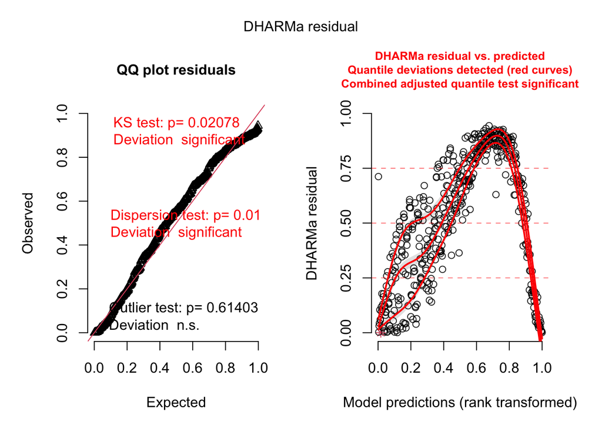

```r
resGammaPesq<- simulateResiduals(modelo_GammaPesq, n=1000)
plot(resGammaPesq)
```

```r
check_model(modelo_GammaPesq)
```

```
## `check_outliers()` does not yet support models of class `glmmTMB`.
```

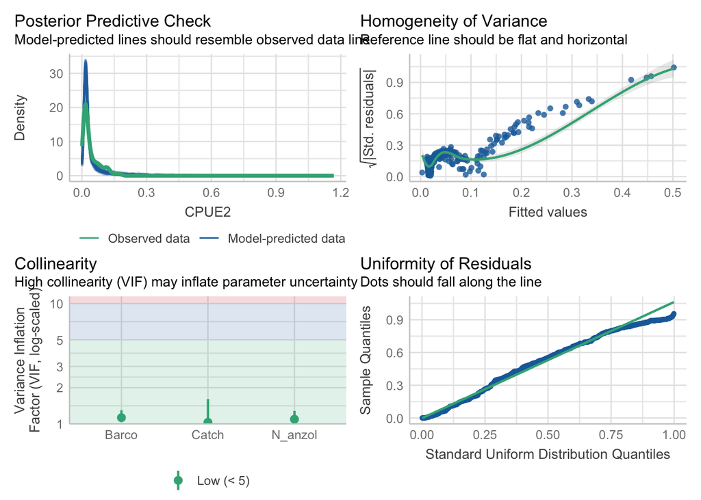

No posterior predictive check vemos que o modelo está sobreestimando os resíduos. No gráfico de homogeneidade de variância há um padrão claro crescente, ou seja, os resíduos aumentam com os valores preditos. Isso indica heterocedasticidade: a variância não é constante. Os valores de colinearidade estão abaixo de 5, o que indica que a colinearidade entre as variáveis não é grande. No Distribution of Quantile Residuals (gráfico inferior direito) idealmente, os pontos deveriam se alinhar à linha diagonal. Visualmente, os resíduos estão relativamente próximos da diagonal, mas algumas pequenas divergências nos extremos podem existir, refletindo que o modelo não captura perfeitamente todos os valores.  
Rodaremos o summary

```r
summary(modelo_GammaPesq)
```

```
##  Family: Gamma  ( log )
## Formula:          CPUE2 ~ Barco + N_anzol + Catch
## Data: dados
##
##       AIC       BIC    logLik -2*log(L)  df.resid
##   -3152.1   -3093.7    1590.0   -3180.1       462
##
##
## Dispersion estimate for Gamma family (sigma^2): 0.0924
##
## Conditional model:
##               Estimate Std. Error z value Pr(>|z|)
## (Intercept) -3.767e+00  9.604e-02  -39.23  < 2e-16 ***
## BarcoV122   -4.334e-02  5.627e-02   -0.77   0.4412
## BarcoV170   -1.207e-01  6.220e-02   -1.94   0.0524 .
## BarcoV192    3.728e-02  6.830e-02    0.55   0.5852
## BarcoV201   -9.407e-02  5.764e-02   -1.63   0.1027
## BarcoV217   -9.183e-02  7.091e-02   -1.30   0.1953
## BarcoV237   -5.326e-02  6.421e-02   -0.83   0.4068
## BarcoV238   -2.058e-02  6.139e-02   -0.34   0.7375
## BarcoV251   -6.058e-02  6.520e-02   -0.93   0.3528
## BarcoV266   -1.162e-03  5.704e-02   -0.02   0.9837
## BarcoV348   -1.472e-02  7.043e-02   -0.21   0.8345
## N_anzol     -5.202e-04  8.375e-05   -6.21 5.28e-10 ***
## Catch        2.027e-02  4.090e-04   49.57  < 2e-16 ***
## ---
## Signif. codes:  0 '***' 0.001 '**' 0.01 '*' 0.05 '.' 0.1 ' ' 1
```

Aparentemente os diferentes Barcos não tiveram influência significativa no CPUE2. Porém o número de anzois teve, por ser um coeficiente negativo significa que quanto mais anzóis, CPUE2 diminui. Já para Catch, o efeito é positivo, quanto maior o Catch maior o CPUE2  
Vamos ver os preditos

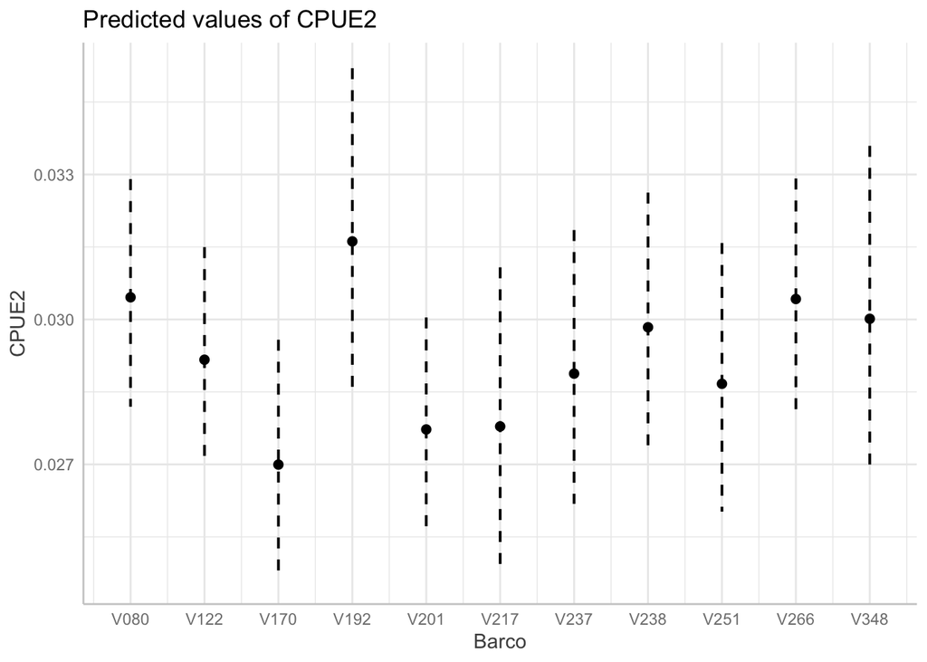

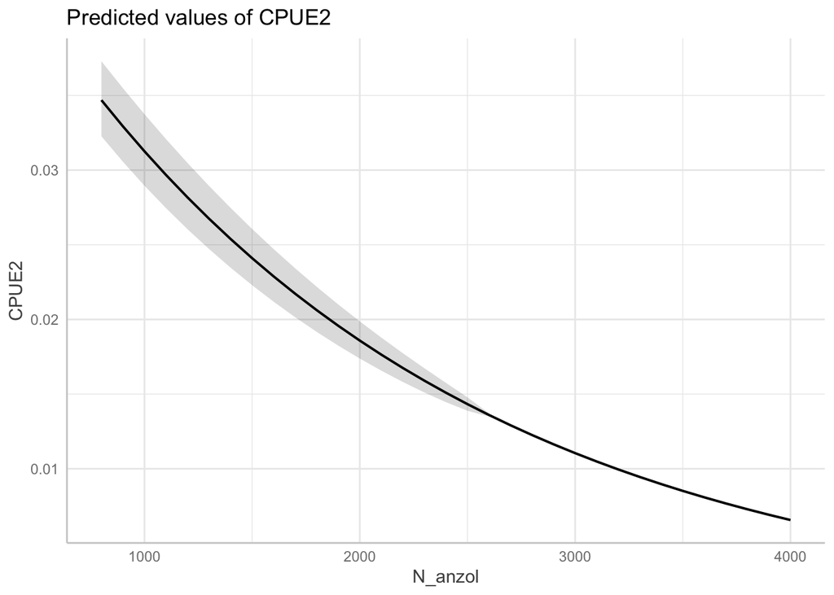

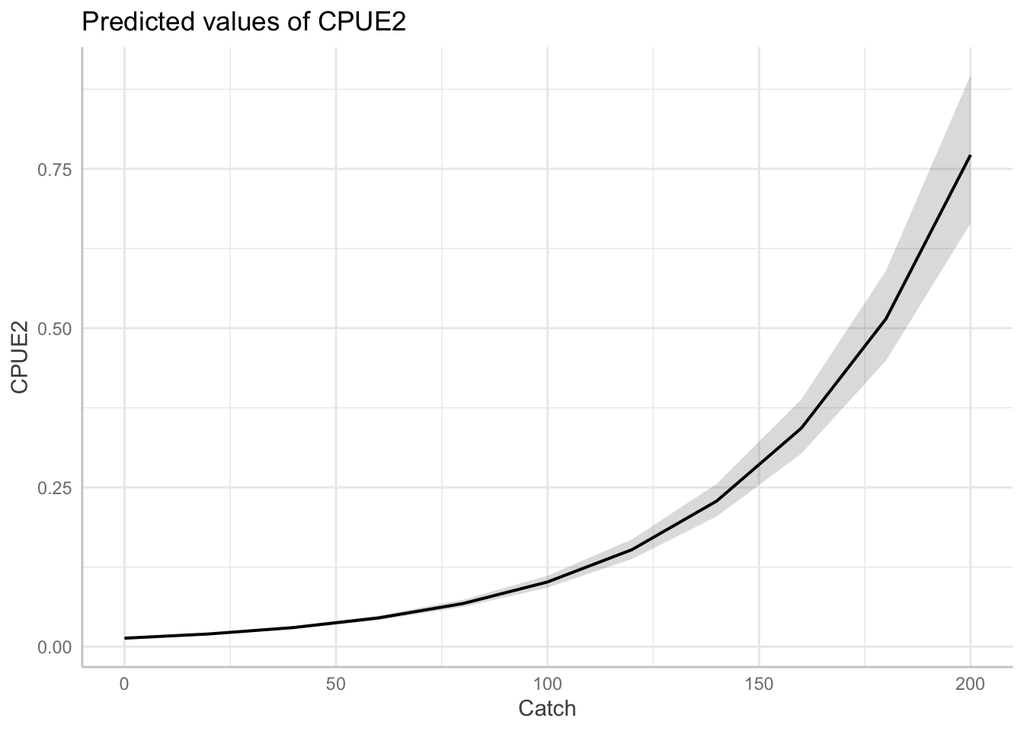

```r
ggpredict(modelo_GammaPesq) %>% plot()
```

No primeiro gráfico que tem os valores preditos de CPUE2 em função de Barco, nós vemos que tem uma pequena variação, sendo o barco V192 com CPUE2 ligeiramente maior. No segundo gráfico vemos que ter mais anzois não significa uma captura maior, que quanto mais anzois mais CPUE2 diminui. E para Catch, quanto mais capturados maior o CPUE2.